# Estudios de Informática, Multimedia y Telecomunicaciones

# Minería de datos: PRA1 - Selección y preparación de un juego de datos

Autor: Jorge Alonso Hernández

Noviembre 2021

# 1 Introducción

## 1.1 Presentación

En esta práctica abordamos un caso real de minería de datos donde tenemos que poner en juego todos los conceptos trabajados en la asignatura. Hay que trabajar todo el ciclo de vida del proyecto, desde el objetivo del proyecto hasta la implementación del conocimiento encontrado, pasando por la preparación, limpieza de los datos, conocimiento de los datos, generación del modelo, interpretación y evaluación. La práctica la dividiremos en dos partes. En esta primera parte (PRA1), abordaremos las primeras fases del proceso, desde los objetivos hasta la preparación de los datos, y en la segunda parte (PRA2) seguiremos con el resto del proceso.

## 1.2 Objetivos

El objetivo global de esta primera parte de la práctica (PRA1) consiste en seleccionar uno o varios juegos de datos, y realizar las tareas de **preparación y análisis exploratorio** con el objetivo de disponer de datos listos para después, en la segunda parte (PRA2), **aplicar algoritmos** de clustering, regresión o clasificación, demostrando la correcta asimilación de todos los aspectos trabajados durante el semestre.

# 2 Descripción de la PRA a realizar

La analítica de datos como actividad profesional, se sustenta en 3 ejes fundamentales. Uno de ellos es el profundo **conocimiento** que deberíamos tener **del problema** al que tratamos de dar respuestas mediante los estudios analíticos. Todo estudio analítico debe nacer de una necesidad por parte del **negocio** o de una necesidad de toma de decisiones basada en los datos y que resolveremos siguiendo las buenas prácticas basadas en la minería de datos. El otro aspecto importante es sin duda las **capacidades analíticas** que seamos capaces de desplegar y en este sentido, las dos prácticas de esta asignatura pretenden que el estudiante realice un recorrido sólido por este segundo eje. El tercer eje son los **datos**. Las necesidades del negocio deben concretarse con preguntas analíticas que sea posible responder a partir de los datos de que disponemos. La tarea de analizar los datos es sin duda importante, pero la tarea de identificarlos y obtenerlos va a ser para un analista un reto permanente.

Como **primera parte** del estudio analítico que nos disponemos a realizar, se pide al estudiante que complete los siguientes pasos:

1. Seleccionar un juego de datos y justificar su elección. El juego de datos deberá permitir resolver alguna pregunta analítica mediante la aplicación de algoritmos supervisados o no supervisados. El juego de datos deberá tener como mínimo 500 observaciones y debe ser distinto del usado en las PEC anteriores. El estudiante deberá visitar los siguientes portales de datos abiertos para seleccionar su juego de datos:
- **Datos abiertos**
  - [Google Dataset Search](https://datasetsearch.research.google.com/)
  - [Datos abiertos España](https://datos.gob.es/es/catalogo?q=&frequency=%7B%22type%22%3A+%22months%22%2C+%22value%22%3A+%221%22%7D&sort=score+desc%2C+metadata_modified+desc)
  - [Datos abiertos Madrid](https://datos.madrid.es/portal/site/egob/)
  - [Datos abiertos Barcelona](https://opendata-ajuntament.barcelona.cat/es/)
  - [Datos abiertos Londres](https://data.london.gov.uk/)
  - [Datos abiertos New York](https://opendata.cityofnewyork.us/)
- **Conjuntos de datos para aprendizaje automático e investigación**
  - [UCI Machine Learning](https://archive.ics.uci.edu/ml/datasets.php)
  - [Datasets for machine-learning research (Wikipedia)](https://en.wikipedia.org/wiki/List_of_datasets_for_machine-learning_research)
  - [Kaggle datasets](https://www.kaggle.com/datasets)

Algún ejemplo del tipo de datos y problemas que podrían elegirse:

[Aprobación de tarjetas de crédito](https://www.kaggle.com/rikdifos/credit-card-approval-prediction) Una tarea de clasificación binaria para predecir si las personas pueden presentar un riesgo de incumplimiento de préstamos de tarjetas de crédito.

[Ventas de comercio electrónico](https://www.kaggle.com/carrie1/ecommerce-data): Predicción de ventas y transacciones en una tienda online. Un problema clásico de predicción de series temporales.

Debéis tener en cuenta que deberéis usar este mismo conjunto de datos, una vez procesado y acondicionado, en los ejercicios de modelado dedatos de la segunda parte de la práctica (PRA2).

2. Plantear un problema de analítica de datos sobre el conjunto de datos seleccionado, detallando los objetivos analíticos y desarrollando una metodología para resolverlos de acuerdo con lo que se ha practicado en las PEC y lo que se ha aprendido en el material didáctico.
3. Realizar un análisis exploratorio del juego de datos seleccionado, utilizando las visualizaciones que crea necesrias para ilustrar su análisis.
4. Realizar las tareas de limpieza y acondicionado necesarias para que los datos puedan ser usados en los consiguientes procesos de modelado.
5. Analizar las diferentes variables y realizar las transformaciones necesarias para la optimización de los procesos de modelado.
6. Realizar un análisis de componentes principales (PCA) o descomposición de valores singulares (SVD) sobre el juego de datos explicando los aspectos más destacados del análisis. Utilizar las componentes obtenidas para visualizar el conjunto de datos, y en su caso, poeéis usar las componentes como variables en el proceso de modelado. Se valorará si además profundizais en alguna otra técnica explicada en el módulo docente de **Preprocesado y gestión de características**.

## 2.1 Recursos

### 2.1.1 Recursos Básicos

Material docente proporcionado por la UOC.

### 2.1.2 Recursos de programación

- Incluimos en este apartado una lista de recursos de programación para minería de datos donde podréis encontrar ejemplos, ideas e inspiración:
  - [Material adicional del libro: Minería de datos Modelos y Algoritmos](http://oer.uoc.edu/libroMD/)
  - [Espacio de recursos UOC para ciencia de datos](http://datascience.recursos.uoc.edu/es/)
  - [Buscador de código R](https://rseek.org/)
  - [Colección de cheatsheets en R](https://rstudio.com/resources/cheatsheets/)

## 2.2 Criterios de valoración

Para todas las PRA es **necesario documentar** en cada apartado del ejercicio práctico que se ha hecho y como se ha hecho. Asimismo, todas las decisiones y conclusiones deberán ser presentados de forma razonada y clara, especificando todos y cada uno de los pasos que se hayan llevado a cabo para su resolución.

## 2.3 Formato y fecha de entrega PRA1

El formato de entrega es: **usernameestudiant-PRA1.Rmd** y **usernameestudiant-PRA1.html** (o .pdf/.docx)  
Se debe entregar la PRA1 en el buzón de entregas del aula

## 2.4 Nota: Propiedad intelectual

> A menudo es inevitable, al producir una obra multimedia, hacer uso de recursos creados por terceras personas. Es por lo tanto comprensible hacerlo en el marco de una práctica de los estudios de Informática, Multimedia y Telecomunicación de la UOC, siempre y cuando esto se documente claramente y no suponga plagio en la práctica.

> Por lo tanto, al presentar una práctica que haga uso de recursos ajenos, se debe presentar junto con ella un documento en que se detallen todos ellos, especificando el nombre de cada recurso, su autor, el lugar donde se obtuvo y su estatus legal: si la obra esta protegida por el copyright o se acoge a alguna otra licencia de uso (Creative Commons, licencia GNU, GPL …). El estudiante deberá asegurarse de que la licencia no impide específicamente su uso en el marco de la práctica. En caso de no encontrar la información correspondiente tendrá que asumir que la obra esta protegida por copyright.

> Deberéis, además, adjuntar los ficheros originales cuando las obras utilizadas sean digitales, y su código fuente si corresponde.

# 3 Desarrollo de la práctica

## 3.1 Elección del conjunto de datos

Para la realización de la práctica se ha escogido un juego de datos referente a los accidentes producidos en la Comunidad de Madrid durante el año 2020 Los datos se han obtenido del [Portal de datos abiertos del Ayuntamiento de Madrid](https://datos.madrid.es/portal/site/egob). Este conjunto de datos contiene la información de los accidentes de tráfico registrados por la Policía Municipal.

Se ha seleccionado este conjunto de datos en primer lugar por estar bastante completo ya que posee bastante información referente a los accidentes, pues para un accidente se tiene registro del lugar del accidente, la fecha, el tipo de accidente, el vehículo implicado, el sexo de la persona implicada, la lesividad de la persona implicada, el estado meteorológico, entre otros datos. Además de que la documentación adjunta al conjunto de datos es bastante clara y precisa.

En segundo lugar, se ha escogido dicho conjunto de datos ya que tiene bastante potencial analítico, ya que un estudio correcto de estos datos puede ser de utilidad para los servicios sanitarios y para la policía.

En el ámbito de los servicios sanitarios los datos podrían ayudar a estar mejor preparados para atender a los heridos de accidentes, así como estimar las fechas o los lugares en los que será necesario reforzar el servicio tanto de urgencias como de unidades móviles en base a las fechas y los distritos donde se producen la mayor cantidad de accidentes o los accidentes más graves.

En cuanto a la policía el estudio puede ayudar a aumentar las patrullas y los controles en los puntos y fechas de mayor frecuencia de accidentes posibilitando la reducción del número de siniestros. También les facilitaría la obtención de un perfil más preciso acerca de los conductores que más accidentes o más accidentes graves ocasionan.

Trabajaremos en un modelo de clasificación de forma que podamos clasificar los accidentes de tráfico que se puedan ocasionar en la Comunidad de Madrid permitiendo a la policía y a los servicios sanitarios optimizar sus recursos de cara a atender a los involucrados en dichos accidentes. De esta forma obtendremos los factores más relevantes a la hora de producirse un accidente de tráfico y permitiendo fijar los factores que implican un accidente de tráfico grave.

Para este estudio construiremos un árbol de decisión que conformaremos a partir de los datos obtenidos. Para la obtención de dicho árbol de decisiones seguiremos una serie de fases:

- **Preparación de los datos:** en esta primera fase de preprocesamiento de los datos nos encargaremos de realizar la limpieza de los datos donde nos encargaremos de corregir aquellos errores que observemos en la muestra para posteriormente realizaremos transformaciones de los datos de forma que obtengamos una serie de variables que mejoren nuestro análisis. Por último, reduciremos nuestra muestra de forma que obtengamos un conjunto de datos lo más preciso posible. El objetivo de esta fase es tener un conjunto de datos con la calidad adecuada y en el formato adecuado para generar un buen modelo de minería de datos.
- **Minería de datos:** En esta fase realizaremos la construcción del modelo de datos propuesto que no se permita realizar la clasificación de los accidentes de tráfico de la Comunidad de Madrid, por tanto el objetivo en esta fase será el de obtener un modelo que permita la clasificación de los siniestros en función de la gravedad de la lesividad.

## 3.2 Exploración del conjunto de datos

```r
ruta_csv <- "C:\\Users\\Jorge\\Documents\\Rstudio Workspace\\Minería de datos\\PRA1\\2020_Accidentalidad.csv"
accidentes <- read.csv2(ruta_csv,na.strings="NA", encoding = "UTF-8")
summary(accidentes)
```

```
##  X.U.FEFF.num_expediente    fecha               hora
##  Length:32427            Length:32427       Length:32427
##  Class :character        Class :character   Class :character
##  Mode  :character        Mode  :character   Mode  :character
##
##
##
##  localizacion          numero            distrito         tipo_accidente
##  Length:32427       Length:32427       Length:32427       Length:32427
##  Class :character   Class :character   Class :character   Class :character
##  Mode  :character   Mode  :character   Mode  :character   Mode  :character
##
##
##
##  estado_meteorológico tipo_vehiculo      tipo_persona        rango_edad
##  Length:32427         Length:32427       Length:32427       Length:32427
##  Class :character     Class :character   Class :character   Class :character
##  Mode  :character     Mode  :character   Mode  :character   Mode  :character
##
##
##
##      sexo            lesividad         coordenada_x_utm coordenada_y_utm
##  Length:32427       Length:32427       Min.   :429069   Min.   :4463495
##  Class :character   Class :character   1st Qu.:439962   1st Qu.:4471803
##  Mode  :character   Mode  :character   Median :441917   Median :4475026
##                                        Mean   :442218   Mean   :4474898
##                                        3rd Qu.:444328   3rd Qu.:4477652
##                                        Max.   :454624   Max.   :4488100
##  positiva_alcohol   positiva_droga
##  Length:32427       Length:32427
##  Class :character   Class :character
##  Mode  :character   Mode  :character
##
##
##
```

```r
str(accidentes)
```

```
## 'data.frame':    32427 obs. of  17 variables:
##  $ X.U.FEFF.num_expediente: chr  "2019S040008" "2019S040008" "2020S000001" "2020S000001" ...
##  $ fecha                  : chr  "07/09/2020" "07/09/2020" "01/01/2020" "01/01/2020" ...
##  $ hora                   : chr  "23:00:00" "23:00:00" "1:15:00" "1:15:00" ...
##  $ localizacion           : chr  "CALL. SAN MAXIMILIANO, 38" "CALL. SAN MAXIMILIANO, 38" "AVDA. CANILLEJAS A VICALVARO / CALL. SILFIDE" "AVDA. CANILLEJAS A VICALVARO / CALL. SILFIDE" ...
##  $ numero                 : chr  "38" "38" "1" "1" ...
##  $ distrito               : chr  "CIUDAD LINEAL" "CIUDAD LINEAL" "SAN BLAS-CANILLEJAS" "SAN BLAS-CANILLEJAS" ...
##  $ tipo_accidente         : chr  "Choque contra obstáculo fijo" "Choque contra obstáculo fijo" "Colisión fronto-lateral" "Colisión fronto-lateral" ...
##  $ estado_meteorológico   : chr  "Despejado" "Despejado" "NULL" "NULL" ...
##  $ tipo_vehiculo          : chr  "Turismo" "VMU eléctrico" "Turismo" "Turismo" ...
##  $ tipo_persona           : chr  "Conductor" "Conductor" "Conductor" "Conductor" ...
##  $ rango_edad             : chr  "De 21 a 24 años" "De 25 a 29 años" "De 18 a 20 años" "De 30 a 34 años" ...
##  $ sexo                   : chr  "Hombre" "Mujer" "Hombre" "Hombre" ...
##  $ lesividad              : chr  "NULL" "NULL" "NULL" "NULL" ...
##  $ coordenada_x_utm       : num  444598 444598 447711 447711 445076 ...
##  $ coordenada_y_utm       : num  4475156 4475156 4477156 4477156 4478372 ...
##  $ positiva_alcohol       : chr  "N" "N" "N" "S" ...
##  $ positiva_droga         : chr  "NULL" "NULL" "NULL" "NULL" ...
```

Verificamos la estructura de datos obtenida de la carga.

```r
str(accidentes)
```

```
## 'data.frame':    32427 obs. of  17 variables:
##  $ X.U.FEFF.num_expediente: chr  "2019S040008" "2019S040008" "2020S000001" "2020S000001" ...
##  $ fecha                  : chr  "07/09/2020" "07/09/2020" "01/01/2020" "01/01/2020" ...
##  $ hora                   : chr  "23:00:00" "23:00:00" "1:15:00" "1:15:00" ...
##  $ localizacion           : chr  "CALL. SAN MAXIMILIANO, 38" "CALL. SAN MAXIMILIANO, 38" "AVDA. CANILLEJAS A VICALVARO / CALL. SILFIDE" "AVDA. CANILLEJAS A VICALVARO / CALL. SILFIDE" ...
##  $ numero                 : chr  "38" "38" "1" "1" ...
##  $ distrito               : chr  "CIUDAD LINEAL" "CIUDAD LINEAL" "SAN BLAS-CANILLEJAS" "SAN BLAS-CANILLEJAS" ...
##  $ tipo_accidente         : chr  "Choque contra obstáculo fijo" "Choque contra obstáculo fijo" "Colisión fronto-lateral" "Colisión fronto-lateral" ...
##  $ estado_meteorológico   : chr  "Despejado" "Despejado" "NULL" "NULL" ...
##  $ tipo_vehiculo          : chr  "Turismo" "VMU eléctrico" "Turismo" "Turismo" ...
##  $ tipo_persona           : chr  "Conductor" "Conductor" "Conductor" "Conductor" ...
##  $ rango_edad             : chr  "De 21 a 24 años" "De 25 a 29 años" "De 18 a 20 años" "De 30 a 34 años" ...
##  $ sexo                   : chr  "Hombre" "Mujer" "Hombre" "Hombre" ...
##  $ lesividad              : chr  "NULL" "NULL" "NULL" "NULL" ...
##  $ coordenada_x_utm       : num  444598 444598 447711 447711 445076 ...
##  $ coordenada_y_utm       : num  4475156 4475156 4477156 4477156 4478372 ...
##  $ positiva_alcohol       : chr  "N" "N" "N" "S" ...
##  $ positiva_droga         : chr  "NULL" "NULL" "NULL" "NULL" ...
```

Para una mayor legibilidad de los datos modificaremos el nombre de la columna “X.U.FEFF.num_expediente” por “num_expediente” y para evitarnos problemas con la codificacion renombraremos también la variable “estado_meteorológico” por “estado_meteorologico”

```r
accidentes <- rename(accidentes, c(X.U.FEFF.num_expediente = "num_expediente"))
accidentes <- rename(accidentes, c(estado_meteorológico = "estado_meteorologico"))
```

Las descripciones de las variables que caracterizan a la muestra de datos son:

- **num_expediente:** número de expediente del accidente. Pueden existir varios registros con el mismo número de expediente debido a que forman parte del mismo accidente donde hay varios afectados
- **fecha:** fecha en la que se produce el accidente
- **hora:** hora en la que se produce el accidente
- **localizacion:** calle en la que se produce el accidente
- **numero:** número de la calle donde se produce el accidente
- **distrito:** distrito donde se produce el accidente
- **tipo_accidente:** corresponde al tipo de accidente, por ejemplo si es una colisión doble, colisión múltiple, atropello, etc.
- **estado_metereologico:** condiciones ambientales que se dan en el momento del siniestro
- **tipo_vehiculo:** tipo del vehículo afectado
- **tipo_persona:** tipo de persona vinculada al accidente, ya sea conductor, viajero, peatón o testigo.
- **rango_edad:** rango de edad de la persona afectada en el siniestro.
- **sexo:** sexo de la persona afectada.
- **lesividad:** gravedad de las lesiones producidas en el accidente.
- **coordenada_x_utm:** coordenada x donde se produce el siniestro.
- **coordenada_y_utm:** coordenada y donde se produce el siniestro.
- **positiva_alcohol:** test de alcoholemia positivo realizado a la persona afectada.
- **positiva_droga:** test de drogas positivo realizado a la persona afectada.

Respecto a los tipos de variables podemos ver que la mayoría de los datos se han cargado como tipo cadena a excepción de las coordenadas, cosa que no es correcta debido que existen variables que deberían ser numéricas como la lesividad, debido a la existencia de la sentencia NULL para cuando no se tiene datos de esta categoría, esto debemos de corregirlo posteriormente para asignarles el tipo de datos correcto. La variable número por su nomenclatura y su definición podría llevarnos a engaño de clasificarla como numérica pero no será el caso al existir números de calle con letras. Otra variable que no ha sido cargada con el tipo de datos correcto es la fecha ya que está como tipo cadena cuando debe de ser tipo date, nuevamente debemos de corregir esto en la etapa de preproceso. Otra transformación que realizar es convertir las variables tipo cadena en tipo factor para su posterior tratamiento.

Vemos las estadísticas básicas de los datos.

```r
summary(accidentes)
```

```
##  num_expediente        fecha               hora           localizacion
##  Length:32427       Length:32427       Length:32427       Length:32427
##  Class :character   Class :character   Class :character   Class :character
##  Mode  :character   Mode  :character   Mode  :character   Mode  :character
##
##
##
##     numero            distrito         tipo_accidente     estado_meteorologico
##  Length:32427       Length:32427       Length:32427       Length:32427
##  Class :character   Class :character   Class :character   Class :character
##  Mode  :character   Mode  :character   Mode  :character   Mode  :character
##
##
##
##  tipo_vehiculo      tipo_persona        rango_edad            sexo
##  Length:32427       Length:32427       Length:32427       Length:32427
##  Class :character   Class :character   Class :character   Class :character
##  Mode  :character   Mode  :character   Mode  :character   Mode  :character
##
##
##
##   lesividad         coordenada_x_utm coordenada_y_utm  positiva_alcohol
##  Length:32427       Min.   :429069   Min.   :4463495   Length:32427
##  Class :character   1st Qu.:439962   1st Qu.:4471803   Class :character
##  Mode  :character   Median :441917   Median :4475026   Mode  :character
##                     Mean   :442218   Mean   :4474898
##                     3rd Qu.:444328   3rd Qu.:4477652
##                     Max.   :454624   Max.   :4488100
##  positiva_droga
##  Length:32427
##  Class :character
##  Mode  :character
##
##
##
```

Al ser la mayoría de las variables de tipo cadena no obtenemos ninguna información reseñable del conjunto de datos. No obtenemos de primera mano la existencia de valores no definidos. Como pudimos ver en la estructura del juego de datos, muchos de los valores no definidos venían con la cadena NULL, por lo tanto, en la fase de preproceso debemos de buscar por esta cadena para poder actuar en consecuencia para mejorar los datos.

Obtenemos la cantidad de valores no definidos del conjunto de datos que no pudimos obtener del resumen.

```r
colSums(is.na(accidentes))
```

```
##       num_expediente                fecha                 hora
##                    0                    0                    0
##         localizacion               numero             distrito
##                    0                    0                    0
##       tipo_accidente estado_meteorologico        tipo_vehiculo
##                    0                    0                    0
##         tipo_persona           rango_edad                 sexo
##                    0                    0                    0
##            lesividad     coordenada_x_utm     coordenada_y_utm
##                    0                    0                    0
##     positiva_alcohol       positiva_droga
##                    0                    0
```

Comprobamos que al ser la mayoría de los datos de tipo cadena no obtenemos valores no definidos (NA). Por lo que realizaremos una primera búsqueda para aquellos valores con cadena vacía.

```r
colSums(accidentes == "" | accidentes == " ")
```

```
##       num_expediente                fecha                 hora
##                    0                    0                    0
##         localizacion               numero             distrito
##                    0                    2                    0
##       tipo_accidente estado_meteorologico        tipo_vehiculo
##                    0                    0                    0
##         tipo_persona           rango_edad                 sexo
##                    0                    0                    0
##            lesividad     coordenada_x_utm     coordenada_y_utm
##                    0                    0                    0
##     positiva_alcohol       positiva_droga
##                    0                    0
```

Por último, comprobamos los valores nulos del juego de datos.

```r
colSums(accidentes == "NULL")
```

```
##       num_expediente                fecha                 hora
##                    0                    0                    0
##         localizacion               numero             distrito
##                    0                    0                    2
##       tipo_accidente estado_meteorologico        tipo_vehiculo
##                    0                 3194                  137
##         tipo_persona           rango_edad                 sexo
##                    0                    0                    0
##            lesividad     coordenada_x_utm     coordenada_y_utm
##                14796                    0                    0
##     positiva_alcohol       positiva_droga
##                  102                32345
```

## 3.3 Preprocesado y gestión de características

Como inicio de la fase de preproceso, realizaremos la sustitución de los valores no definidos o nulos por los valores correspondientes. Iniciaremos con la variable de lesividad dado que conocemos de antemano los valores por los que debemos sustituir. Sustituimos los valores vacíos por el valor 14 correspondiente a “Sin asistencia sanitaria” y los valores nulos por el valor 77 “Se desconoce”. Una vez hecho el cambio convertimos el tipo de dato de la variable al tipo entero.

```r
accidentes$lesividad[accidentes$lesividad == "" | accidentes$lesividad == " "] = 14
accidentes$lesividad[accidentes$lesividad == "NULL"] = 77
accidentes$lesividad <- as.integer(accidentes$lesividad)
```

Para una mayor legibilidad de los datos, convertiremos los valores nulos de los test de drogas y test de alcohol por el valor “No realizado”. También transformaremos los valores nulos del estado meteorológico, el numero de la calle, el tipo de persona, el tipo de accidente y el tipo de vehículo por el valor “Desconocido”

```r
accidentes$positiva_alcohol[accidentes$positiva_alcohol == "NULL"] <- "No realizado"
accidentes$positiva_droga[accidentes$positiva_droga == "NULL"] <- "No realizado"
accidentes$estado_meteorologico[accidentes$estado_meteorologico == "NULL" | accidentes$estado_meteorologico == "Se desconoce"] <- "Desconocido"
accidentes$numero[accidentes$numero == "NULL"] <- "Desconocido"
accidentes$tipo_persona[accidentes$tipo_persona == "NULL"] <- "Desconocido"
accidentes$tipo_vehiculo[accidentes$tipo_vehiculo == "NULL" | accidentes$tipo_vehiculo == "Sin especificar"] <- "Desconocido"
accidentes$tipo_accidente[accidentes$tipo_accidente == "NULL"] <- "Desconocido"
```

Realizamos las conversiones de tipos de datos necesarias.

```r
accidentes$fecha <- as.Date(accidentes$fecha)
accidentes$sexo = as.factor(accidentes$sexo)
accidentes$distrito = as.factor(accidentes$distrito)
accidentes$tipo_persona = as.factor(accidentes$tipo_persona)
accidentes$tipo_vehiculo = as.factor(accidentes$tipo_vehiculo)
accidentes$tipo_accidente = as.factor(accidentes$tipo_accidente)
accidentes$estado_meteorologico = as.factor(accidentes$estado_meteorologico)
accidentes$rango_edad = as.factor(accidentes$rango_edad)
accidentes$positiva_alcohol = as.factor(accidentes$positiva_alcohol)
accidentes$positiva_droga = as.factor(accidentes$positiva_droga)

sapply(accidentes,class)
```

```
##       num_expediente                fecha                 hora
##          "character"               "Date"          "character"
##         localizacion               numero             distrito
##          "character"          "character"             "factor"
##       tipo_accidente estado_meteorologico        tipo_vehiculo
##             "factor"             "factor"             "factor"
##         tipo_persona           rango_edad                 sexo
##             "factor"             "factor"             "factor"
##            lesividad     coordenada_x_utm     coordenada_y_utm
##            "integer"            "numeric"            "numeric"
##     positiva_alcohol       positiva_droga
##             "factor"             "factor"
```

EL siguiente paso que realizaremos será el de discretizar la variable de lesividad, obteniendo dos nuevas variables una con una categorización más general de la lesividad del accidente y otra con la categorización específica. Para la obtención de estas nuevas variables discretizaremos cada uno de los códigos de lesividad a su correspondiente categoría que se especifica en la documentación del juego de datos.

La categorización general especificada en la documentación es la siguiente:

| Código lesividad | Grado lesividad |
| --- | --- |
| 01 | Leve |
| 02 | Leve |
| 03 | Grave |
| 04 | Mortal |
| 05 | Leve |
| 06 | Leve |
| 07 | Leve |
| 14 | Sin asistencia |
| 77 | Desconocido |

Discretizamos la lesividad en categorías generales:

```r
accidentes$grado_lesividad <- ""
accidentes$grado_lesividad[accidentes$lesividad == 1 | accidentes$lesividad == 2 | accidentes$lesividad == 5 | accidentes$lesividad == 6 | accidentes$lesividad == 7] <- "Leve"
accidentes$grado_lesividad[accidentes$lesividad == 3] <- "Grave"
accidentes$grado_lesividad[accidentes$lesividad == 4] <- "Mortal"
accidentes$grado_lesividad[accidentes$lesividad == 14] <- "Sin asistencia"
accidentes$grado_lesividad[accidentes$lesividad == 77] <- "Desconocido"

accidentes$grado_lesividad <- as.factor(accidentes$grado_lesividad)
```

Observamos una muestra de la variable resultante

```r
head(accidentes$grado_lesividad)
```

```
## [1] Desconocido Desconocido Desconocido Desconocido Desconocido Desconocido
## Levels: Desconocido Grave Leve Mortal Sin asistencia
```

La categorización específica indicada en la documentación es la siguiente:

| Código lesividad | Grado lesividad |
| --- | --- |
| 01 | Asistencia en urgencias sin posterior ingreso |
| 02 | Ingreso inferior o igual a 24 horas |
| 03 | Ingreso superior a 24 horas |
| 04 | Fallecido 24 horas |
| 05 | Asistencia ambulatoria con posterioridad |
| 06 | Asistencia sanitaria inmediata en centro de salud o mutua |
| 07 | Asistencia sanitaria sólo en el lugar del accidente |
| 14 | Sin asistencia sanitaria |
| 77 | Se desconoce |

Discretizamos la lesividad en categorías específicas.

```r
accidentes$categoria_lesividad <- ""
accidentes$categoria_lesividad[accidentes$lesividad == 1] <- "Asistencia en urgencias sin posterior ingreso"
accidentes$categoria_lesividad[accidentes$lesividad == 2] <- "Ingreso inferior o igual a 24 horas"
accidentes$categoria_lesividad[accidentes$lesividad == 3] <- "Ingreso superior a 24 horas"
accidentes$categoria_lesividad[accidentes$lesividad == 4] <- "Fallecido 24 horas"
accidentes$categoria_lesividad[accidentes$lesividad == 5] <- "Asistencia ambulatoria con posterioridad"
accidentes$categoria_lesividad[accidentes$lesividad == 6] <- "Asistencia sanitaria inmediata en centro de salud o mutua"
accidentes$categoria_lesividad[accidentes$lesividad == 7] <- "Asistencia sanitaria sólo en el lugar del accidente"
accidentes$categoria_lesividad[accidentes$lesividad == 14] <- "Sin asistencia sanitaria"
accidentes$categoria_lesividad[accidentes$lesividad == 77] <- "Se desconoce"


accidentes$categoria_lesividad <- as.factor(accidentes$categoria_lesividad)
```

Mostramos los resultados de la nueva variable.

```r
head(accidentes$categoria_lesividad)
```

```
## [1] Se desconoce Se desconoce Se desconoce Se desconoce Se desconoce
## [6] Se desconoce
## 9 Levels: Asistencia ambulatoria con posterioridad ...
```

Vemos ahora la cantidad de accidentes agrupados por su lesividad general.

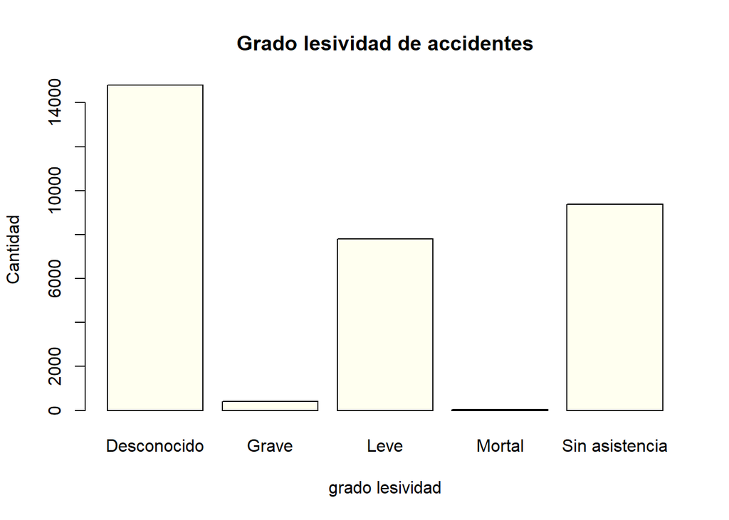

```r
plot(accidentes$grado_lesividad, main="Grado lesividad de accidentes", xlab="grado lesividad", ylab="Cantidad", col="ivory")
```

Podemos observar que la cantidad de accidentes mortales es bastante ínfima en comparación con los accidentes que no necesitaron asistencia sanitaria o un ingreso superior a las 24 horas, un caso parecido lo tenemos con los accidentes graves donde hay un mayor número de accidentes de este tipo que de los accidentes mortales. por último, destaca la gran cantidad de accidentes de los que se desconoce el grado de lesividad.

Mostramos ahora la cantidad de accidentes agrupados por su categorización de lesividad.

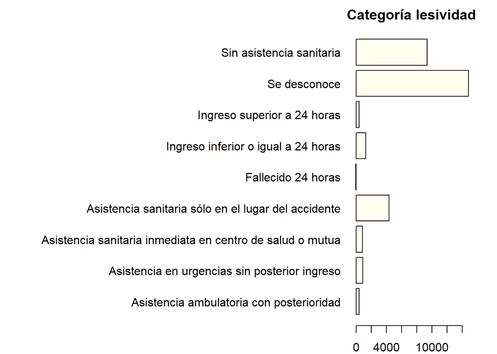

```r
par(mar=c(2,25,2,2))
barplot(table(accidentes$categoria_lesividad), main="Categoría lesividad", horiz = TRUE, las=1, col="ivory")
```

Como era de esperar tras lo visto en el gráfico anterior predomina los accidentes con lesividad desconocida. Se puede apreciar que en la mayoría de los accidentes o se requirió asistencia sanitaria y si se necesitó no hizo falta el traslado a urgencias, sino que se atendieron en el lugar del accidente.

Obtenemos ahora una nueva variable que va a corresponder con el mes en el que se producen los siniestros.

```r
accidentes$mes <- factor(months(accidentes$fecha), levels=c("January", "February", "March", "April", "May", "June", "July", "August", "September", "October", "November", "December"))
head(accidentes$mes)
```

```
## [1] September September January   January   January   January
## 12 Levels: January February March April May June July August ... December
```

Mostramos los resultados de la nueva variable obtenida.

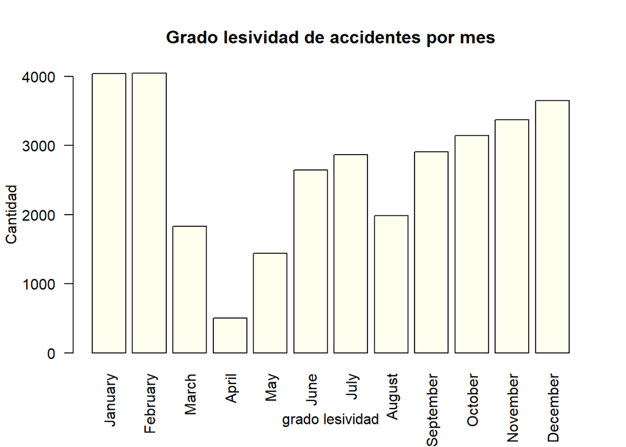

```r
plot(accidentes$mes, main="Grado lesividad de accidentes por mes", xlab="grado lesividad", ylab="Cantidad", col="ivory", las=2)
```

En este caso podemos comprobar que los meses con más incidencias de tráfico corresponden con los meses de enero y febrero notándose una gran disminución en los meses primaverales y de nuevo un aumento gradual en los meses otoñales siendo con bastante diferencia los meses de invierno en los que más accidentes de tráfico se producen, esto puede deberse a las condiciones climatológicas.

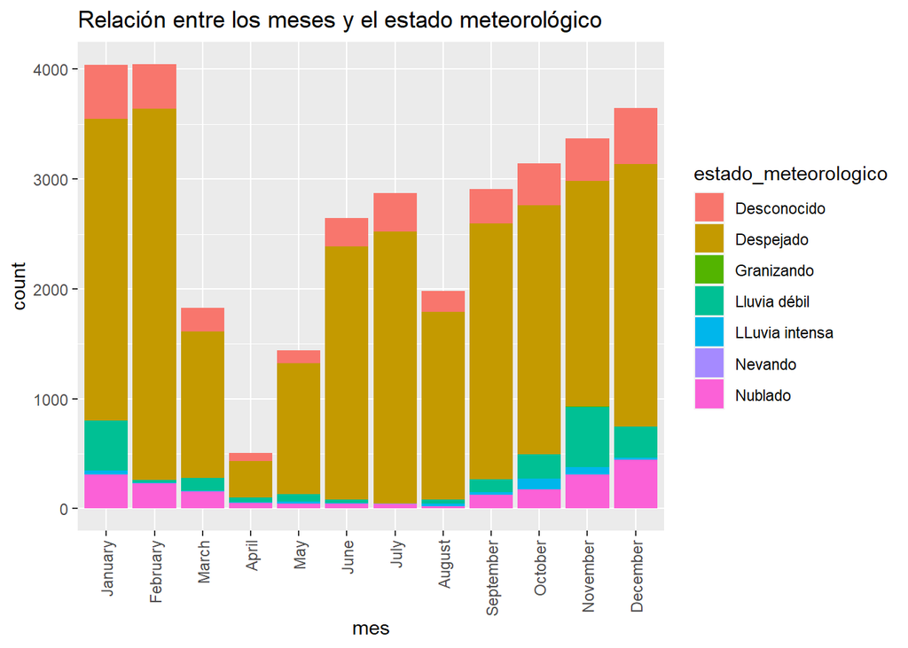

```r
ggplot(data=accidentes, aes(x=mes, fill=estado_meteorologico))+geom_bar()+ggtitle("Relación entre los meses y el estado meteorológico")+scale_x_discrete(guide = guide_axis(angle = 90))
```

Observamos que el clima predominante en los siniestros producidos durante los meses de invierno es el clima despejado, y no se observan estados meteorológicos adversos significativos en estos meses, con lo cual podemos determinar que el estado meteorológico no es el principal motivo que provoca los accidentes.

Vemos el grado de lesividad en función del mes en el que se produce el siniestro.

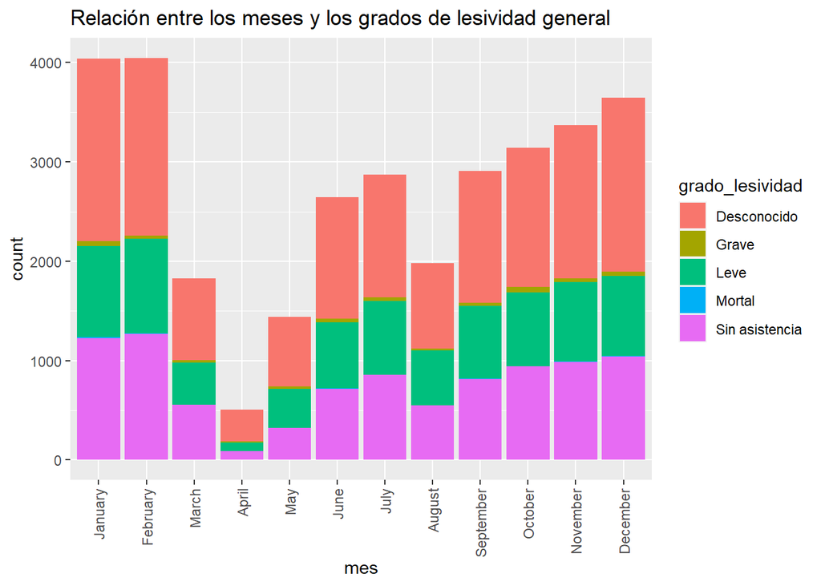

```r
ggplot(data=accidentes, aes(x=mes, fill=grado_lesividad))+geom_bar()+ggtitle("Relación entre los meses y los grados de lesividad general")+scale_x_discrete(guide = guide_axis(angle = 90))
```

Se puede apreciar que no existe diferencia significativa entre cada uno de los meses y que se reparten los diferentes grados de lesividad de forma similar en cada uno de los meses, no pudiendo obtener un mes destacable en el que se produzca un mayor número de accidentes graves.

Analizamos ahora el grado de lesividad de los diferentes rangos de edad en función de su sexo.

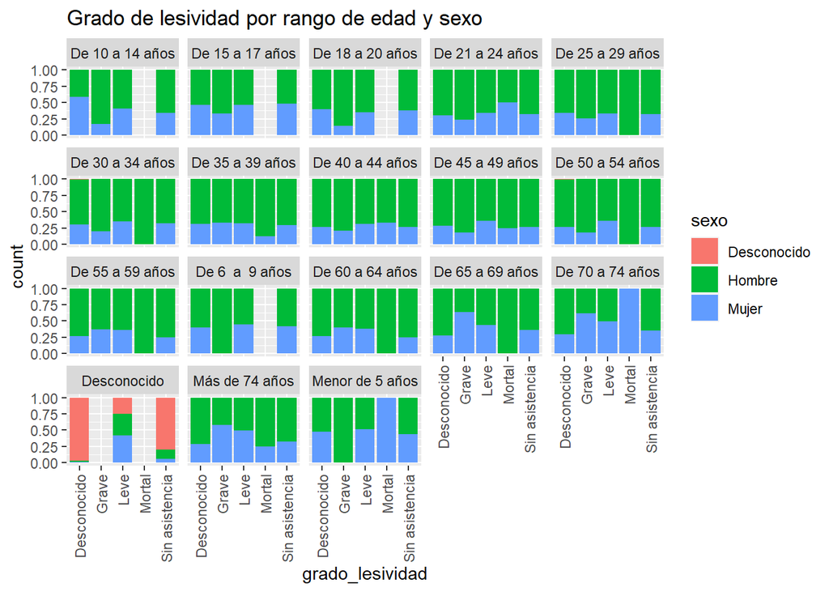

```r
ggplot(data = accidentes,aes(x=grado_lesividad,fill=sexo))+geom_bar(position="fill")+facet_wrap(~rango_edad)+ggtitle("Grado de lesividad por rango de edad y sexo")+scale_x_discrete(guide = guide_axis(angle = 90))
```

Podemos destacar que la mayor parte de los implicados en los siniestros son Hombres. Predominando la mortalidad en estos a excepción de personas menores de 5 años y de 70 a 74 años donde las únicas víctimas son mujeres.

La última discretización que vamos a realizar consistirá en obtener el momento del día en el que se produce el accidente en función de la hora, clasificaremos las horas entre Mañana, Tarde, Noche y Madrugada.

```r
accidentes$partes_dia <- factor(cut(hour(hms(accidentes$hora)), breaks = c(-0.01,5.9,11.9,18.9, 24), labels = c("Madrugada","Mañana", "Tarde", "Noche"), right=TRUE), levels = c("Mañana", "Tarde", "Noche", "Madrugada"))
```

Mostramos los resultados obtenidos.

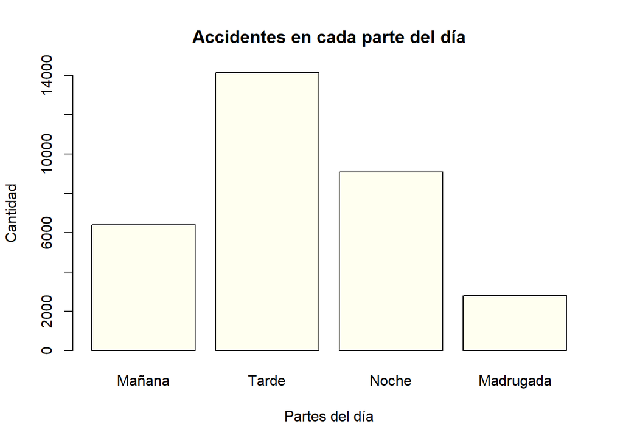

```r
plot(accidentes$partes_dia, main="Accidentes en cada parte del día", xlab="Partes del día", ylab="Cantidad", col="ivory")
```

Podemos observar que en este caso la mayoría de los accidentes se produjeron por la tarde en el periodo entre las 12 AM y las 19 PM.

Mostramos ahora los accidentes en función del grado de lesividad por cada una de las partes del día.

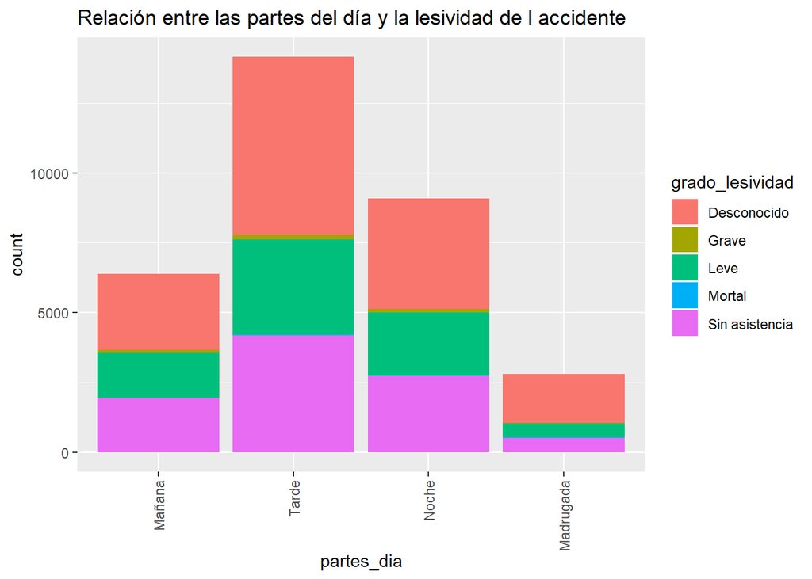

```r
ggplot(data=accidentes, aes(x=partes_dia, fill=grado_lesividad))+geom_bar()+ggtitle("Relación entre las partes del día y la lesividad de l accidente")+scale_x_discrete(guide = guide_axis(angle = 90))
```

Nuevamente podemos apreciar que somos capaces de reconocer la parte del día en la que más accidentes se producen pero no la parte del día en al que mas accidentes graves o mortales se ocasionan.

Por último mostramos las coordenadas en los que han tenido lugar los accidentes.

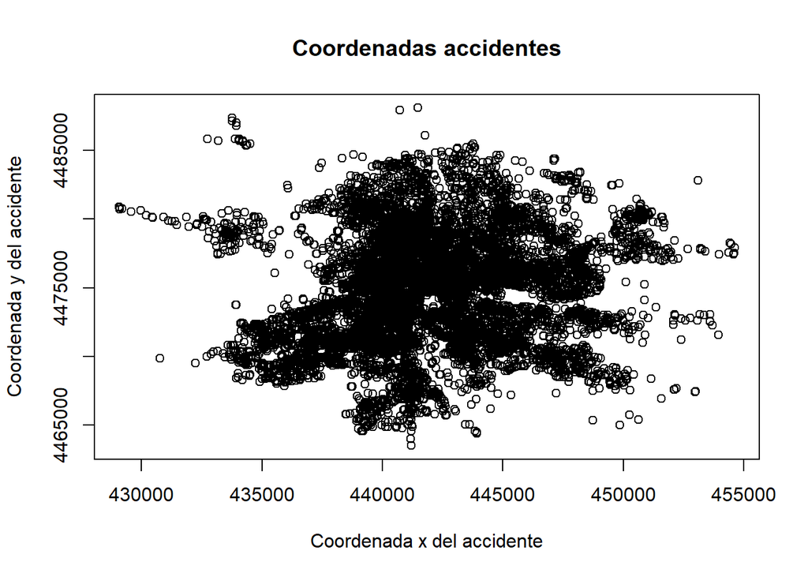

```r
plot(accidentes$coordenada_x_utm,accidentes$coordenada_y_utm, main="Coordenadas accidentes", xlab="Coordenada x del accidente", ylab = "Coordenada y del accidente")
```

Podemos observar que se concentra más en el centro en lo que podemos considerar el centro de la Comunidad de Madrid, observando conforme se va saliendo del centro los accidentes van disminuyendo hasta ser bastante escasos.

Como hemos podido observar durante la exploración de los datos, el grado de lesividad predominante es el de Desconocido, lo cual empañará los resultados obtenidos en el análisis, por lo tanto, reduciremos la muestra eliminando aquellos siniestros de los cuales se desconoce la lesividad de los implicados. También reduciremos el número de variables obteniendo sólo las que consideramos de interés para el modelo a realizar.

```r
accidentesFinal=subset(accidentes, accidentes$grado_lesividad != "Desconocido", select = c(distrito, tipo_accidente, estado_meteorologico, tipo_vehiculo, tipo_persona, rango_edad, sexo, positiva_alcohol, positiva_droga, grado_lesividad, categoria_lesividad, mes, partes_dia))
nrow(accidentesFinal)
```

```
## [1] 17628
```

Podemos observar que la muestra de datos se ha visto reducida a un total de 17628 registros.

## 3.4 Construcción de conjunto de datos final

El conjunto de datos final contiene un total de 17628 registros caracterizados por 13 variables que hemos considerado como las más relevantes para poder clasificar los accidentes de tráficos ocasionas en la Comunidad de Madrid.

las variables seleccionadas son:

- **distrito:** distrito donde se produce el accidente. Con el tenemos localizado y agrupado geográficamente los accidentes.
- **tipo_accidente:** corresponde al tipo de accidente. Relevante en relación con obtener la gravedad de la lesividad del siniestro.
- **estado_meteorologico:** condiciones ambientales que se dan en el momento del siniestro. COmprobaremos si influye finalmente en el grado de lesividad de un accidente, pese a que el estudio previo no es concluyente.
- **tipo_vehiculo:** tipo de vehículo afectado. Comprobaremos si la gravedad de un accidente va ligado al tipo de vehículo implicado.
- **tio_persona:** tipo de persona vinculada al accidente. Veremos cómo afecta en la gravedad de un accidente el ser pasajero o conductor.
- **rango_edad:** rango de edad de la persona afectada en el siniestro. Comprobaremos si la edad es un factor de riesgo que provoca accidentes.
- **sexo:** seco de la persona afectada. Veremos la relación de sexos con los accidentes, pese a que en el estudio previo hemos visto que los hombres son más propensos a tener accidentes.
- **positiva_alcohol:** test de alcoholemia positivo realizado a la persona afectada. Veremos si afecta a la gravedad del siniestro.
- **positiva_droga:** test de drogas positivo realizado a la persona afectada. veremos si afecta a la gravedad del siniestro, pese a que en el estudio previo hemos visto que prácicamente no se realzian test de drogas, pero podemos analizar si realizando más test de drogas podemos disminuir la gravedad de los accidentes o es irrelevante.
- **grado_lesividad:** grado de la lesividad de la persona implicada en el siniestro. Nos sirve para medir la lesividad de los accidentes.
- **categoria_lesividad:** categoría específica de la lesividad de la persona implicada en el siniestro. Nos sirve para medir la lesividad de los accidentes de forma más concreta.
- **mes:** mes en el que se produce el accidente. Veremos su implicación con la gravedad de los siniestros, aunque hemos visto en el estudio previo que los accidentes tienden a haber más accidentes en invierno.
- **partes_dia:** parte del día en la que se produce el accidentes. Veremos su implicación con la gravedad e los siniestros, en el estudio previo pudimos ver que se producen más accidentes durante la tarde.

Con todas estas variables, realizaremos el árbol de decisiones, en el cual determinaremos la gravedad de un accidente. Veremos qué condiciones son realmente relevantes a la hora de producirse un accidente grave o mortal. Podremos obtener las partes del día, los meses y los distritos que deberán de reforzarse con tal de prevenir accidentes.

Mostramos un ejemplo del conjunto de datos final.

```r
head(accidentesFinal)
```

```
##       distrito          tipo_accidente estado_meteorologico       tipo_vehiculo
## 18 CARABANCHEL        Colisión lateral            Despejado             Turismo
## 19   SALAMANCA Colisión fronto-lateral            Despejado Motocicleta > 125cc
## 20   SALAMANCA Colisión fronto-lateral            Despejado             Turismo
## 21   SALAMANCA Colisión fronto-lateral            Despejado             Turismo
## 31   CHAMARTÍN        Colisión frontal            Despejado             Turismo
## 32   CHAMARTÍN        Colisión frontal            Despejado             Turismo
##    tipo_persona      rango_edad   sexo positiva_alcohol positiva_droga
## 18     Pasajero De 45 a 49 años Hombre                N   No realizado
## 19    Conductor De 40 a 44 años Hombre                N   No realizado
## 20    Conductor De 25 a 29 años  Mujer                N   No realizado
## 21     Pasajero De 25 a 29 años  Mujer                N   No realizado
## 31    Conductor De 35 a 39 años Hombre                N   No realizado
## 32    Conductor De 55 a 59 años  Mujer                N   No realizado
##    grado_lesividad         categoria_lesividad     mes partes_dia
## 18  Sin asistencia    Sin asistencia sanitaria January  Madrugada
## 19           Grave Ingreso superior a 24 horas January     Mañana
## 20  Sin asistencia    Sin asistencia sanitaria January     Mañana
## 21  Sin asistencia    Sin asistencia sanitaria January     Mañana
## 31  Sin asistencia    Sin asistencia sanitaria January  Madrugada
## 32  Sin asistencia    Sin asistencia sanitaria January  Madrugada
```

```r
tail(accidentesFinal)
```

```
##                distrito          tipo_accidente estado_meteorologico
## 32405         HORTALEZA Colisión fronto-lateral         Lluvia débil
## 32410         HORTALEZA       Colisión múltiple            Despejado
## 32411         HORTALEZA       Colisión múltiple            Despejado
## 32412         HORTALEZA       Colisión múltiple            Despejado
## 32413         HORTALEZA       Colisión múltiple            Despejado
## 32424 VILLA DE VALLECAS     Atropello a persona         Lluvia débil
##       tipo_vehiculo tipo_persona      rango_edad   sexo positiva_alcohol
## 32405       Turismo    Conductor De 21 a 24 años Hombre                N
## 32410 Camión rígido    Conductor De 35 a 39 años Hombre                N
## 32411     Furgoneta    Conductor De 25 a 29 años Hombre                N
## 32412       Turismo    Conductor De 25 a 29 años Hombre                N
## 32413       Turismo    Conductor De 60 a 64 años  Mujer                N
## 32424       Turismo       Peatón De 45 a 49 años  Mujer                N
##       positiva_droga grado_lesividad
## 32405   No realizado  Sin asistencia
## 32410   No realizado  Sin asistencia
## 32411   No realizado  Sin asistencia
## 32412   No realizado  Sin asistencia
## 32413   No realizado            Leve
## 32424   No realizado            Leve
##                                 categoria_lesividad      mes partes_dia
## 32405                      Sin asistencia sanitaria December      Tarde
## 32410                      Sin asistencia sanitaria December      Tarde
## 32411                      Sin asistencia sanitaria December      Tarde
## 32412                      Sin asistencia sanitaria December      Tarde
## 32413           Ingreso inferior o igual a 24 horas December      Tarde
## 32424 Asistencia en urgencias sin posterior ingreso December     Mañana
```

Por último, obtenemos el conjunto de datos final en un fichero csv.

```r
  write.csv2(accidentesFinal, "accidentes.csv")
```

# 4 Criterios de evaluación

- 10%. Justificación de la elección del juego de datos donde se detalle el potencial analítico que se intuye.
- 10% Se plantea un problema propio de minería de datos, se detallan los objetivos analíticos y se explica detalladamente el procedimiento para darles solución.
- 20%. Información extraída del análisis exploratorio. Distribuciones, correlaciones, anomalías …
- 20%. Explicación clara de cualquier tarea de limpieza, acondicionado o transformación que se realiza sobre los datos, justificando el motivo y mencionando las ventajas de la acción tomada.
- 20%. Se realiza un proceso de PCA o SVD donde se aprecia mediante explicaciones y comentarios que el estudiante entiende todos los pasos y se comenta extensamente el resultado final obtenido. Se usan las componentes obtenidas para apoyar el análisis propuesto.
- 20%. Se obtiene un conjunto de datos preparado y descrito adecuadamente, especificando las variables que se usarán en los procesos de modelado posterior, y como se aplicarán los métodos propuestos sobre ellas.